[figure not shown]

## Markdown (y Rmarkdown)

### Documentos sencillos, rápidos, y versátiles

#### Daniel Morillo

#### Universidad Autónoma de Madrid

##### 24 de junio de 2020

# Bienvenidos/as

[interactive chart not shown]

# Introducción a Markdown

### ¿Qué es Markdown?

[figure not shown]

# Introducción a Markdown

**Markdown** es…

un *lenguaje de marcado*:

Texto

+

Marcas de formato

```markdown
# Introducción a Markdown

**Markdown** es...

un _lenguaje de marcado_:

Texto

\+

Marcas de formato
```

Tiene “trampa”:  
Animaciones, columnas

# Introducción a Markdown

**Markdown** *también* es…

- un [*conversor* a HTML](http://spec.commonmark.org/dingus/):

[interactive chart not shown]

Pero hay otros: [Pandoc](http://pandoc.org/)

# Pandoc

Permite convertir a:

- HTML
- Word
- PDF

[interactive chart not shown]

# ¿Por qué usar Markdown?

Es *muy legible*:

```markdown
# Título 1


## Título 2

**negrita** y _cursiva_

* puntos

* importantes

1. lista de

1. elementos

1. numerados
```

# Título 1

## Título 2

**negrita** y *cursiva*

- puntos
- importantes
1. lista de
2. elementos
3. numerados

# ¿Por qué usar Markdown?

Es *muy legible*:

```markdown
### Título 3

#### Título 4

[enlace](https://www.ccomsuam.org/)

![logo MD](www/assets/markdown-mark-white.svg)

>Si buscas resultados distintos,
>no hagas siempre lo mismo.

--Albert Einstein
```

## Título 3

### Título 4

[enlace](https://www.ccomsuam.org/)

> Si buscas resultados distintos, no hagas siempre lo mismo.

–Albert Einstein

# ¿Por qué usar Markdown?

Aunque permite insertar:

- HTML/CSS:

```html
<center style='color:lightblue'>Estoy centrado y en azul</center>
```

Estoy centrado y en azul

# ¿Por qué usar Markdown?

Aunque permite insertar:

- $\LaTeX$:

```latex
$Y = \beta_1 X + \epsilon$
```

$Y = \beta_1 X + \epsilon$

# ¿Por qué usar Markdown?

Es *muy rápido*:

[figure not shown]

Contenido

[figure not shown]

Formato

# ¿Por qué usar Markdown?

Es *interoperable*

MS Word:

[interactive chart not shown]

[Markdown](https://daringfireball.net/projects/markdown/syntax):

[interactive chart not shown]

# Pero…

- No es *WYSIWYG*:

*(what you see is what you get)*

[interactive chart not shown]

# Pero…

- Requiere herramientas específicas de colaboración

[figure not shown]

# Aprender Markdown

Es [**extremadamente sencillo**](https://daringfireball.net/projects/markdown/basics):

[interactive chart not shown]

# Aprender Markdown

También conviene conocer [*extensiones comunes*](https://www.markdownguide.org/cheat-sheet/#extended-syntax):

[figure not shown]

# Rmarkdown

### ¿Qué es Rmarkdown?

[figure not shown]

# ¿Qué es Rmarkdown?

**Extensión** de markdown

Consiste en:

[figure not shown]

# ¿Qué es Rmarkdown?

##### Cálculos

```markdown
    PERCENT <- n_control / n_total * 100

El grupo control representó el `r PERCENT`% del total.
```

El grupo control representó el 31.5% del total.

# ¿Qué es Rmarkdown?

##### Gráficos

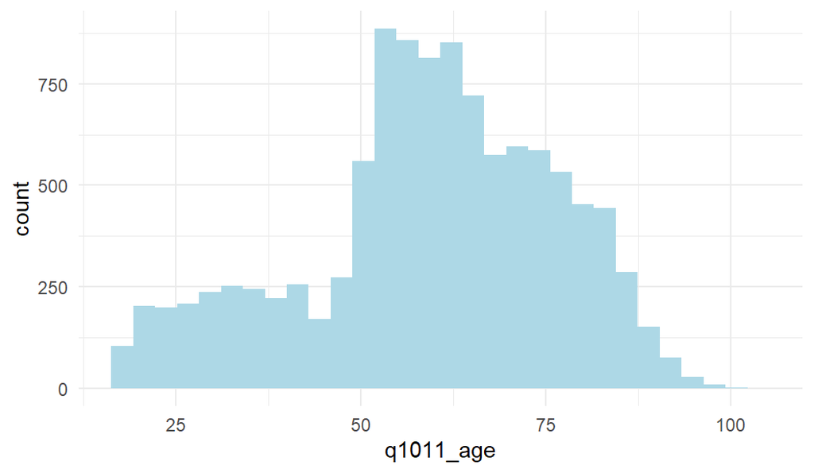

```r
ecs_bl %>% ggplot(aes(x = q1011_age)) + geom_histogram(fill = "lightblue")
```

# ¿Qué es Rmarkdown?

##### Tablas

```r
ecs_bl %>% as_factor() %>% count(q0001_rc, proxy) %>% kable()
```

| q0001_rc | proxy | n |
| --- | --- | --- |
| Finland | Yes | 42 |
| Finland | No | 1934 |
| Poland | Yes | 131 |
| Poland | No | 3940 |
| Spain | Yes | 170 |
| Spain | No | 4583 |

# ¿Qué es Rmarkdown?

**Extensión** de markdown

Consiste en:

Encabezado (YAML):

```yaml
---
title: "Habits"
output:
  pdf_document:
    toc: true
    number_sections: true
---
```

(Ejemplo de [R Markdown: The Definitive Guide](https://bookdown.org/yihui/rmarkdown/pdf-document.html#table-of-contents-1))

# Formatos

### **HTML**

- [Documento HTML](https://bookdown.org/yihui/rmarkdown/pdf-document.html)
- [Sitio web](https://bookdown.org/yihui/blogdown/)
- [Presentación HTML](https://bookdown.org/yihui/rmarkdown/revealjs.html) (e.g., [esta misma](https://github.com/DaniMori/seminario_markdown/blob/master/Seminario_markdown.Rmd))

# Formatos

### **HTML**

```r
leaflet() %>% addTiles() %>%
  addMarkers(lng   = -3.690926, lat   = 40.481403, popup = "CCOMS UAM")
```

[interactive chart not shown]

# Formatos

### **Otros**

- [PowerPoint](https://bookdown.org/yihui/rmarkdown/powerpoint-presentation.html)
- [Libro](https://bookdown.org/yihui/bookdown/):
  - [Web Book](https://bookdown.org/yihui/bookdown/html.html)
  - [PDF](https://bookdown.org/yihui/bookdown/latexpdf.html)
  - [ePub](https://bookdown.org/yihui/bookdown/e-books.html)

# Formatos

### **Documentos**

- [Word](https://bookdown.org/yihui/rmarkdown/word-document.html)
- [PDF](https://bookdown.org/yihui/rmarkdown/pdf-document.html)

# Ejemplo

- Documento (múltiples formatos)

[interactive chart not shown]

# Ejemplo

- Artículo

[interactive chart not shown]

# Ejemplo

- Reenviar un artículo

[interactive chart not shown]

# ¿Merece la pena aprender?

- Markdown
- Rstudio
- R
- Nociones de HTML y $\LaTeX$

# ¿Merece la pena aprender?

1. Ahorro de esfuerzos
2. Desarrollo profesional
3. Ciencia abierta: Reproducibilidad + Replicabilidad

# Una agradable sorpresa…

[interactive chart not shown]

# Flujo de trabajo

- Automatización con Rmarkdown:

[interactive chart not shown]

# Conclusión

Markdown es…

- legible
- productivo
- fácil de editar
- fácil de mantener

# Conclusión

Rmarkdown…

- es versátil
- es gratis!
- evita trabajo repetitivo
- facilita la **reproducibilidad**

# Saber más

- [Página de markdown](https://daringfireball.net/projects/markdown/)
- [Extensiones de markdown](https://www.markdownguide.org/cheat-sheet/#extended-syntax)
- [Curso de Rmarkdown en Rstudio](https://rmarkdown.rstudio.com/lesson-1.html)
- [Chuleta de Rmarkdown](https://rstudio.com/wp-content/uploads/2016/03/rmarkdown-cheatsheet-2.0.pdf)
- [Guía de referencia de Rmarkdown](https://rstudio.com/wp-content/uploads/2015/03/rmarkdown-reference.pdf)

# Saber (aún) más

- [Rstudio Education](https://education.rstudio.com/)
- [R for Data Science](https://r4ds.had.co.nz/)
- [RMarkdown for Scientists](https://rmd4sci.njtierney.com/)
- [RMarkdown for Medicine](https://rmd4medicine.netlify.app/)
- [Communicating with RMarkdown](https://ysc-rmarkdown.netlify.app/)
- [Advanced RMarkdown Workshop](https://arm.rbind.io/)

# “Retos”

## Nivel 1: Tutorial markdown

- Ir a https://www.markdowntutorial.com/
- Hacer click en *Ready? Let’s get started!*
- Completar tutorial

# “Retos”

- [R](https://cran.r-project.org/) (elige Sistema Operativo)
- [Rstudio Desktop Free](https://rstudio.com/products/rstudio/download/)
- TinyTeX ([más información](https://yihui.org/tinytex/)):

```r
install.packages("tinytex")
library(tinytex)
install_tinytex()
```

- Crea un “documento PDF” a partir de una [plantilla de Rmarkdown](https://rmarkdown.rstudio.com/articles_integration.html#file-templates)

# “Retos”

## Nivel 3: Replicar guía de instalación de OneDrive

- Instala [revealjs](https://cran.r-project.org/web/packages/revealjs/index.html) desde Rstudio:

```r
install.packages("revealjs")
```

- Crea un [nuevo proyecto en Rstudio](https://support.rstudio.com/hc/en-us/articles/200526207-Using-Projects)
- Descarga [`Protocolo_entrevista_experiencias.Rmd`](https://github.com/DaniMori/seminario_markdown/blob/master/www/Protocolo_entrevista_experiencias.Rmd)  
  para usarlo como plantilla
- Descarga [estas imágenes](https://github.com/DaniMori/seminario_markdown/tree/master/www/oneDrive_img)
- Usando la plantilla y las imágenes, replica en Rmarkdown la `Guía de sincronización de OneDrive`

# FIN

### Eso ha sido todo

### ¡Muchas gracias!

# Atribuciones

[Markdownguide.org](https://www.markdownguide.org/)

[Rstudio.com](https://rstudio.com/)

[R-project.org](https://www.r-project.org/logo/)

[Iconfinder.com](https://www.iconfinder.com/icons/465052/compose_content_document_pencil_script_sheet_write_icon)

[Iconfinder.com](https://www.iconfinder.com/icons/887655/brush_content_format_graphic_paint_painter_tool_icon)

[Giphy.com](https://media.giphy.com/media/9PekRRQ0WlrRVwynAk/giphy.gif)

[Pngkey.com](https://www.pngkey.com/detail/u2w7i1i1r5t4t4u2_collaboration-icon-icon/)